# Data Description

## Section 1

Our project is about unemployment rates in King, Snohomish, Pierce, Clark, and Spokane counties in Washington compared to their respective coronavirus infection rates by month in 2020.The coronavirus is the most dangerous virus in 2020 and it affects not only people’s lives but also the economy. People who work in entertainment industry (restaurants, cinemas, etc.) may lose their jobs because of the quarantine that prevents people from going outdoors. Higher infection rates may cause stricter quarantine policies and will cause higher unemployment rates as a result. We will analyze if there is actually a connection between the unemployment rates and the infection rates in the community.

We analyze unemployment rates with respective to infection rates because unemployment does not only affect those who have jobs, it also affects those people who are searching for jobs and the community’s economy. The unemployment can cause a chain reaction that makes more people lose jobs and shortens up the service provided in the community, which as a result affect people’s lives in a negative way. If we can find out a positive linear connection between unemployment rates and infection rates, we may be able to control unemployment rate by reducing infection rates through better practical policies.

There are two existing analysis involves unemployment and coronavirus. The first one is the impact of the coronavirus (COVID-19) pandemic on [The Employment Situation for December 2020](https://www.bls.gov/news.release/archives/empsit_01082021.htm).The second one is a research that concludes that unemployment rose higher in three months of COVID-19 than it did in two years of the [Great Recession by Rakesh Kochhar](https://www.pewresearch.org/fact-tank/2020/06/11/unemployment-rose-higher-in-three-months-of-covid-19-than-it-did-in-two-years-of-the-great-recession/)

## Section 2

### What is the data?

The infection rate or volume and unemployment claims for the chosen 5 counties (King, Pierce, Spokane, Clark, Snohomish) from Washington State.

### Sample of The Data

```
##         County WeekStartDate ProbableCases ConfirmedCases TotalCases Age.0.19
## 1 Adams County    2020-01-18             0             27         27        4
## 2 Adams County    2020-03-15             0              3          3        0
## 3 Adams County    2020-03-22             0             13         13        0
## 4 Adams County    2020-03-29             0             17         17        2
## 5 Adams County    2020-04-05             0              8          8        1
## 6 Adams County    2020-04-12             0              2          2        0
##   Age.20.39 Age.40.59 Age.60.79 Age.80. UnknownAge         dtm_updated
## 1        12         7         4       0          0 2021/01/25 14:53:11
## 2         0         3         0       0          0 2021/01/25 14:53:11
## 3         2         5         6       0          0 2021/01/25 14:53:11
## 4         8         4         3       0          0 2021/01/25 14:53:11
## 5         2         4         1       0          0 2021/01/25 14:53:11
## 6         1         1         0       0          0 2021/01/25 14:53:11
```

```
## # A tibble: 6 x 3
##   County Month Unemployment_Claims
##   <chr>  <chr>               <dbl>
## 1 Clark  Jan                  1656
## 2 Clark  Feb                  1065
## 3 Clark  Mar                 16560
## 4 Clark  Apr                 22763
## 5 Clark  May                 13710
## 6 Clark  Jun                  4931
```

### What Are The Columns?

- Probable Causes = Possible Cases
- Confirmed Cases = Total Confirmed Cases
- Total Cases = Possible Cases Plus the Total Confirmed Cases
- Age = Total Confirmed Cases For Each Age Bracket
- Jan-Dec = Total Number of Reported Unemployed For Each COunty Per Month

## Subsection 2.2 Summary Analysis

### Summary Of Data

In the first data set highlighting COVID infections, the total number of Confirmed Covid Cases throughout Washington State is 288948. With the average for one single week being 176.1878049. Furthermore, as most of the data is complete or is filled with a 0, a simple replacement of NA values with 0 cleans up the data.

### Example Plots

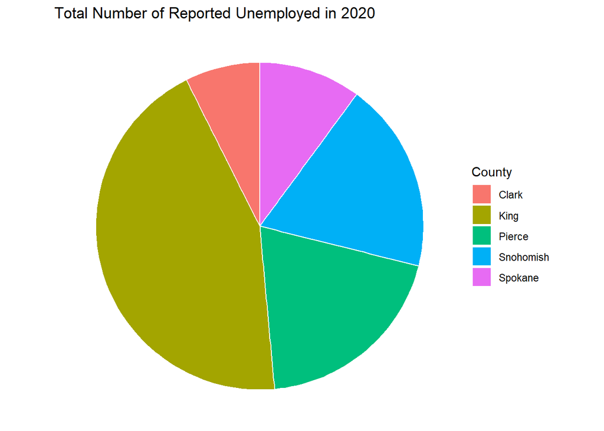

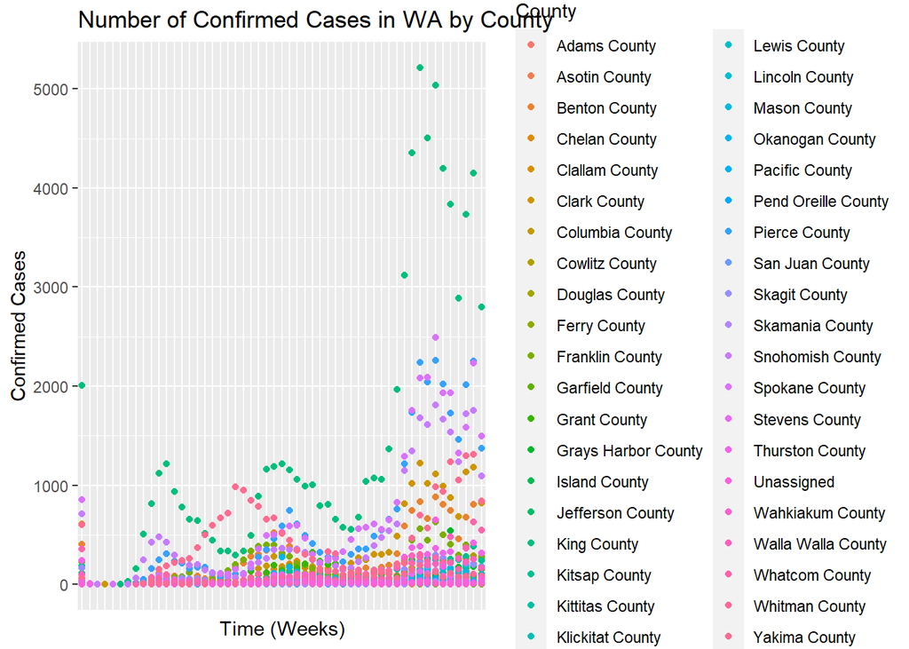

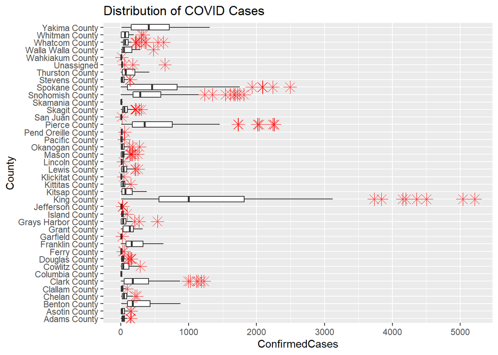

### Notable Outliers

Most of the collected data is quite clean and therefore don’t have many outliers, especially for the unemployment dataframe. However, it can be noted that the county with the highest reported covid cases is King County as also evident in the “Distribution of COVID Cases” Box Plot. Furthermore, the maximum for unemployment in WA is King in the month of April at a volume of 137755. The lowest being Clark in the month of Feburary at a volume of 1065.

# Section 3

## Brandon

### Do COVID-19 infection rates impact the rate of unemployment in King, Snohomish, Pierce, Clark and Spokane counties?

1.We have decided to use population data, covid case data, and unemployment claim data. Using this we could determine the infection rates in each county by dividing the number of confirmed cases by the population number in 2021. Then we were able to find the rate of unemployment similarly by dividing the number of unemployment claims by the population.

2.My data analysis method started with a lot of data wrangling. Because my original data was very different to be able to join them together. I had to do things like get rid of “County” at the end of each County for a few datasets, I also had to try to join a data set together by two columns, but because I couldn’t figure out how to do that I created an extra column with both of those values in each dataset and then joined using that column. To calculate my infection rate, and unemployment rate I mutated the data and then divided the number of cases or claims by the population in each county in 2021. This left we with a data frame of all the information I needed to start creating my plots.

The unemployment rate with highest covid infection rate is 0.0121 and the county with highest infection rate is Spokane.

The unemployment rate with highest covid case is 0.0089 and the county with highest covid cases is King.

### How has the total number of unemployment claims corresponded with the number of COVID-19 cases in Washington?

1. This question is looking at if the data can show us a distinct relationship between the number of cases and claims per month. The data will be taken from the 5 most populous counties in Washington (Clark, King, Pierce, Snohomish, and Spokane).
2. My analysis method was oriented around bringing the data to the same scale, monthly, and then finding the monthly total for both categories. I started by adjusting the data sets and adding a “Month” column, I then group by “Month” and summed up the totals for each county every month. Then, I created a scatterplot comparing the two dataframes of the unemployment and covid-19 data.

```
## geom_path: Each group consists of only one observation. Do you need to adjust
## the group aesthetic?
```

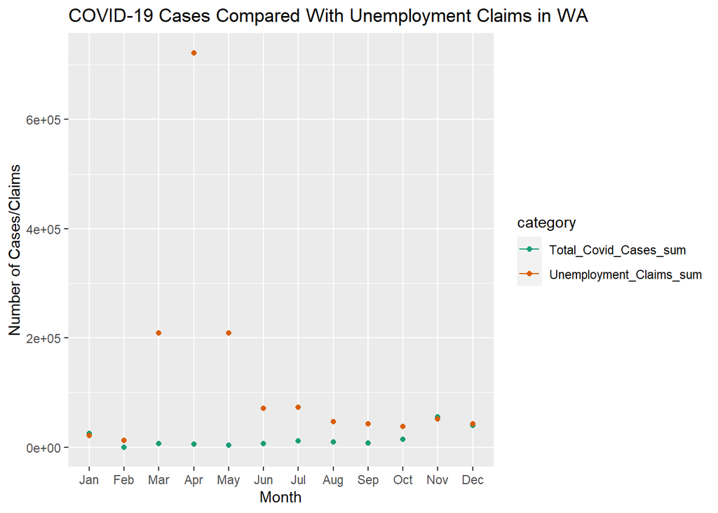

4. My initial hypothesis was that cases would have a strong correlation with claims, but I found that not to be true, obvious in the large disparity throughout the middle of the year. However, in the early and late months of the year, the ratio of cases to claims is high, 0.93 in December and 1.19 in January. This led me to the hypothesis that this is because as COVID-19 first hit, we lacked preparation and as a result, cases were able to hit at full force. This lead to jobs shutting down, but the infection rate was maximized. As the year went on, jobs remained closed and more shut down, increasing the claim count to a maximum of 722037 claims in April. However, with jobs and schools being shut down, the infection rate was mitigated, making it so cases did not increase at the same rate as the unemployment claims. Then as time passed, jobs opened up and restrictions loosened, letting people get employment, decreasing the claims back down in Decemeber, however this led to a similar context as in the beginning of the year, where cases matched claims because of loose restrictions. As we entered 2021, restrictions came back and so I would expect the same pattern to arise from it.

2. My data analysis method was to get the data for each county and sum up the data so that there were totals for each month for every county. I then plotted this in a scatter plot. This format seems messy at first but I think it is a great way to see all of the data from a raw standpoint.

```
## geom_path: Each group consists of only one observation. Do you need to adjust
## the group aesthetic?
```

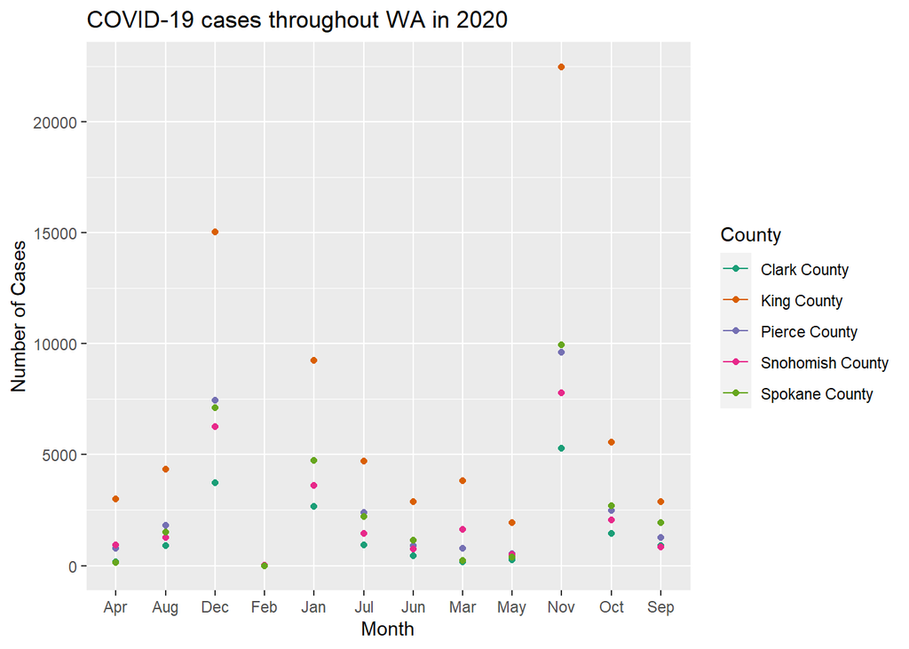

A table displaying quarterly case data on 2 of the counties. King being most populated and Clark being one of the least populated.

[output not shown]